# Signal Pre-Processing

## Library Imports

```python
import numpy as np
import pandas as pd
import matplotlib.pyplot as plt
from scipy.interpolate import interp1d
from scipy.signal import welch, butter, filtfilt, freqz
from scipy.fftpack import fft
```

## 1

##### Read data file(s) given in data.zip. There are several simultaneously measured and time synced signals (ecg and two ppg sensors both containing three channels with different wavelengths).

##### 1.1. Loading the data

```python
motion_df = pd.read_csv('data/ecg_ppg_motion.csv')
clean_df = pd.read_csv('data/ecg_ppg_clean.csv')
```

##### 1.2. Check if there are any remaining NaN values

```python
motion_df.isna().sum()
```

```
timestamps_ecg               0
ecg                          0
timestamps_ppg_1_green    3524
ppg_1_green               3524
timestamps_ppg_1_red      3524
ppg_1_red                 3524
timestamps_ppg_1_ir       3524
ppg_1_ir                  3524
timestamps_ppg_2_green    3523
ppg_2_green               3523
timestamps_ppg_2_red      3523
ppg_2_red                 3523
timestamps_ppg_2_ir       3523
ppg_2_ir                  3523
dtype: int64
```

```python
clean_df.isna().sum()
```

```
timestamps_ecg               0
ecg                          0
timestamps_ppg_1_green    3455
ppg_1_green               3455
timestamps_ppg_1_red      3455
ppg_1_red                 3455
timestamps_ppg_1_ir       3455
ppg_1_ir                  3455
timestamps_ppg_2_green    3455
ppg_2_green               3455
timestamps_ppg_2_red      3455
ppg_2_red                 3455
timestamps_ppg_2_ir       3455
ppg_2_ir                  3455
dtype: int64
```

##### 1.3. Imputing missing values for both dataframes with the mean of each column. Although it is a simple method for imputation but it is effective and maintains the overall distribution of the data.

```python
motion_df.fillna(motion_df.mean())
```

|  | timestamps_ecg | ecg | timestamps_ppg_1_green | ppg_1_green | timestamps_ppg_1_red | ppg_1_red | timestamps_ppg_1_ir | ppg_1_ir | timestamps_ppg_2_green | ppg_2_green | timestamps_ppg_2_red | ppg_2_red | timestamps_ppg_2_ir | ppg_2_ir |
| --- | --- | --- | --- | --- | --- | --- | --- | --- | --- | --- | --- | --- | --- | --- |
| 0 | 763530.0 | -1395.000000 | 763536.0 | 30428.000000 | 763536.0 | 2.275115e+06 | 763536.0 | 2.546066e+06 | 763512.0 | 21303.000000 | 763512.0 | 2.273412e+06 | 763512.0 | 2.267852e+06 |
| 1 | 763608.0 | -1353.531646 | 763636.0 | 30448.792079 | 763636.0 | 2.275110e+06 | 763636.0 | 2.546067e+06 | 763612.0 | 21315.745098 | 763612.0 | 2.273418e+06 | 763612.0 | 2.267880e+06 |
| 2 | 763686.0 | -1101.531646 | 763736.0 | 30440.178218 | 763736.0 | 2.275118e+06 | 763736.0 | 2.546061e+06 | 763712.0 | 21326.673267 | 763712.0 | 2.273422e+06 | 763712.0 | 2.267867e+06 |
| 3 | 763764.0 | -878.544304 | 763836.0 | 30463.058824 | 763836.0 | 2.275130e+06 | 763836.0 | 2.546074e+06 | 763812.0 | 21333.656863 | 763812.0 | 2.273415e+06 | 763812.0 | 2.267844e+06 |
| 4 | 763842.0 | -820.632911 | 763936.0 | 30473.504950 | 763936.0 | 2.275127e+06 | 763936.0 | 2.546079e+06 | 763912.0 | 21345.176471 | 763912.0 | 2.273398e+06 | 763912.0 | 2.267842e+06 |
| ... | ... | ... | ... | ... | ... | ... | ... | ... | ... | ... | ... | ... | ... | ... |
| 16007 | 2012076.0 | 40.400000 | 1387886.0 | 30485.989392 | 1387886.0 | 2.274772e+06 | 1387886.0 | 2.545607e+06 | 1387912.0 | 22107.057692 | 1387912.0 | 2.273699e+06 | 1387912.0 | 2.270375e+06 |
| 16008 | 2012154.0 | -911.645570 | 1387886.0 | 30485.989392 | 1387886.0 | 2.274772e+06 | 1387886.0 | 2.545607e+06 | 1387912.0 | 22107.057692 | 1387912.0 | 2.273699e+06 | 1387912.0 | 2.270375e+06 |
| 16009 | 2012232.0 | -3209.037975 | 1387886.0 | 30485.989392 | 1387886.0 | 2.274772e+06 | 1387886.0 | 2.545607e+06 | 1387912.0 | 22107.057692 | 1387912.0 | 2.273699e+06 | 1387912.0 | 2.270375e+06 |
| 16010 | 2012310.0 | -4635.620253 | 1387886.0 | 30485.989392 | 1387886.0 | 2.274772e+06 | 1387886.0 | 2.545607e+06 | 1387912.0 | 22107.057692 | 1387912.0 | 2.273699e+06 | 1387912.0 | 2.270375e+06 |
| 16011 | 2012388.0 | -2907.974684 | 1387886.0 | 30485.989392 | 1387886.0 | 2.274772e+06 | 1387886.0 | 2.545607e+06 | 1387912.0 | 22107.057692 | 1387912.0 | 2.273699e+06 | 1387912.0 | 2.270375e+06 |

16012 rows × 14 columns

```python
clean_df.fillna(clean_df.mean())
```

|  | timestamps_ecg | ecg | timestamps_ppg_1_green | ppg_1_green | timestamps_ppg_1_red | ppg_1_red | timestamps_ppg_1_ir | ppg_1_ir | timestamps_ppg_2_green | ppg_2_green | timestamps_ppg_2_red | ppg_2_red | timestamps_ppg_2_ir | ppg_2_ir |
| --- | --- | --- | --- | --- | --- | --- | --- | --- | --- | --- | --- | --- | --- | --- |
| 0 | 725290.0 | -1949.000000 | 725314.0 | 31289.000000 | 725314.0 | 2.274565e+06 | 725314.0 | 2.544369e+06 | 725301.0 | 28101.000000 | 725301.0 | 2.534342e+06 | 725301.0 | 2.540145e+06 |
| 1 | 725368.0 | -1737.708861 | 725414.0 | 31255.336634 | 725414.0 | 2.274575e+06 | 725414.0 | 2.544328e+06 | 725401.0 | 28117.666667 | 725401.0 | 2.534269e+06 | 725401.0 | 2.539954e+06 |
| 2 | 725446.0 | -1534.215190 | 725514.0 | 31204.029703 | 725514.0 | 2.274564e+06 | 725514.0 | 2.544304e+06 | 725501.0 | 28114.156863 | 725501.0 | 2.534142e+06 | 725501.0 | 2.539586e+06 |
| 3 | 725524.0 | -1413.556962 | 725614.0 | 31186.504950 | 725614.0 | 2.274553e+06 | 725614.0 | 2.544289e+06 | 725601.0 | 28101.764706 | 725601.0 | 2.533956e+06 | 725601.0 | 2.539082e+06 |
| 4 | 725602.0 | -1333.050633 | 725714.0 | 31166.029412 | 725714.0 | 2.274524e+06 | 725714.0 | 2.544271e+06 | 725701.0 | 28083.490196 | 725701.0 | 2.533720e+06 | 725701.0 | 2.538444e+06 |
| ... | ... | ... | ... | ... | ... | ... | ... | ... | ... | ... | ... | ... | ... | ... |
| 15696 | 1949578.0 | -795.746835 | 1337564.0 | 31158.075124 | 1337564.0 | 2.274819e+06 | 1337564.0 | 2.544813e+06 | 1337551.0 | 28128.415823 | 1337551.0 | 2.533084e+06 | 1337551.0 | 2.538999e+06 |
| 15697 | 1949656.0 | -713.493671 | 1337564.0 | 31158.075124 | 1337564.0 | 2.274819e+06 | 1337564.0 | 2.544813e+06 | 1337551.0 | 28128.415823 | 1337551.0 | 2.533084e+06 | 1337551.0 | 2.538999e+06 |
| 15698 | 1949734.0 | -620.556962 | 1337564.0 | 31158.075124 | 1337564.0 | 2.274819e+06 | 1337564.0 | 2.544813e+06 | 1337551.0 | 28128.415823 | 1337551.0 | 2.533084e+06 | 1337551.0 | 2.538999e+06 |
| 15699 | 1949812.0 | -590.886076 | 1337564.0 | 31158.075124 | 1337564.0 | 2.274819e+06 | 1337564.0 | 2.544813e+06 | 1337551.0 | 28128.415823 | 1337551.0 | 2.533084e+06 | 1337551.0 | 2.538999e+06 |
| 15700 | 1949890.0 | -599.392405 | 1337564.0 | 31158.075124 | 1337564.0 | 2.274819e+06 | 1337564.0 | 2.544813e+06 | 1337551.0 | 28128.415823 | 1337551.0 | 2.533084e+06 | 1337551.0 | 2.538999e+06 |

15701 rows × 14 columns

##### 1.4. Plotting signals from the motion_df. The below code actually plots ECG signal first against the timestamps that is available in the motion_df extracted from the file ecg_ppg_motion file. Apart from the ECG plotting it also holds the code for plotting different wavelengths of the PPGs from both the sensors.

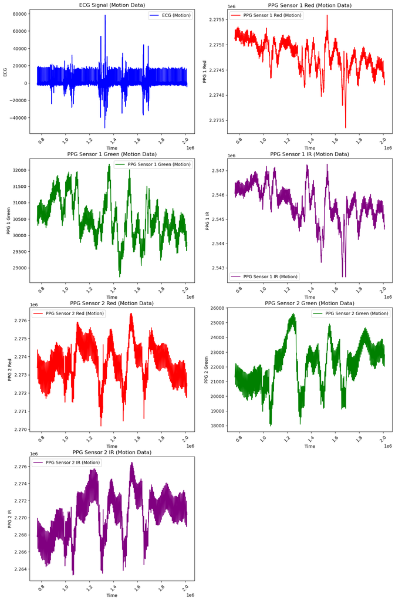

```python
# Define figure size
plt.figure(figsize=(15, 30))

# ECG Signal
plt.subplot(5, 2, 1)
plt.plot(motion_df['timestamps_ecg'], motion_df['ecg'], label='ECG (Motion)', color='blue')
plt.xlabel('Time')
plt.ylabel('ECG')
plt.title('ECG Signal (Motion Data)')
plt.xticks(rotation=45)
plt.legend()

# PPG Sensor 1 Red
plt.subplot(5, 2, 2)
plt.plot(motion_df['timestamps_ppg_1_red'], motion_df['ppg_1_red'], label='PPG Sensor 1 Red (Motion)', color='red')
plt.xlabel('Time')
plt.ylabel('PPG 1 Red')
plt.title('PPG Sensor 1 Red (Motion Data)')
plt.xticks(rotation=45)
plt.legend()

# PPG Sensor 1 Green
plt.subplot(5, 2, 3)
plt.plot(motion_df['timestamps_ppg_1_green'], motion_df['ppg_1_green'], label='PPG Sensor 1 Green (Motion)', color='green')
plt.xlabel('Time')
plt.ylabel('PPG 1 Green')
plt.title('PPG Sensor 1 Green (Motion Data)')
plt.xticks(rotation=45)
plt.legend()

# PPG Sensor 1 IR
plt.subplot(5, 2, 4)
plt.plot(motion_df['timestamps_ppg_1_ir'], motion_df['ppg_1_ir'], label='PPG Sensor 1 IR (Motion)', color='purple')
plt.xlabel('Time')
plt.ylabel('PPG 1 IR')
plt.title('PPG Sensor 1 IR (Motion Data)')
plt.xticks(rotation=45)
plt.legend()

# PPG Sensor 2 Red
plt.subplot(5, 2, 5)
plt.plot(motion_df['timestamps_ppg_2_red'], motion_df['ppg_2_red'], label='PPG Sensor 2 Red (Motion)', color='red')
plt.xlabel('Time')
plt.ylabel('PPG 2 Red')
plt.title('PPG Sensor 2 Red (Motion Data)')
plt.xticks(rotation=45)
plt.legend()

# PPG Sensor 2 Green
plt.subplot(5, 2, 6)
plt.plot(motion_df['timestamps_ppg_2_green'], motion_df['ppg_2_green'], label='PPG Sensor 2 Green (Motion)', color='green')
plt.xlabel('Time')
plt.ylabel('PPG 2 Green')
plt.title('PPG Sensor 2 Green (Motion Data)')
plt.xticks(rotation=45)
plt.legend()

# PPG Sensor 2 IR
plt.subplot(5, 2, 7)
plt.plot(motion_df['timestamps_ppg_2_ir'], motion_df['ppg_2_ir'], label='PPG Sensor 2 IR (Motion)', color='purple')
plt.xlabel('Time')
plt.ylabel('PPG 2 IR')
plt.title('PPG Sensor 2 IR (Motion Data)')
plt.xticks(rotation=45)
plt.legend()
```

##### 1.5. Plotting signals from the clean_df. The below code actually plots ECG signal first against the timestamps that is available in the clean_df extracted from the file ecg_ppg_clean file. Apart from the ECG plotting it also holds the code for plotting different wavelengths of the PPGs from both the sensors.

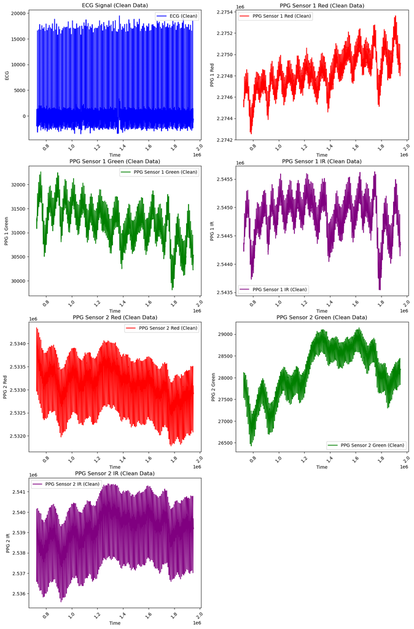

```python
plt.figure(figsize=(15, 30))

# ECG Signal
plt.subplot(5, 2, 1)
plt.plot(clean_df['timestamps_ecg'], clean_df['ecg'], label='ECG (Clean)', color='blue')
plt.xlabel('Time')
plt.ylabel('ECG')
plt.title('ECG Signal (Clean Data)')
plt.xticks(rotation=45)
plt.legend()

# PPG Sensor 1 Red
plt.subplot(5, 2, 2)
plt.plot(clean_df['timestamps_ppg_1_red'], clean_df['ppg_1_red'], label='PPG Sensor 1 Red (Clean)', color='red')
plt.xlabel('Time')
plt.ylabel('PPG 1 Red')
plt.title('PPG Sensor 1 Red (Clean Data)')
plt.xticks(rotation=45)
plt.legend()

# PPG Sensor 1 Green
plt.subplot(5, 2, 3)
plt.plot(clean_df['timestamps_ppg_1_green'], clean_df['ppg_1_green'], label='PPG Sensor 1 Green (Clean)', color='green')
plt.xlabel('Time')
plt.ylabel('PPG 1 Green')
plt.title('PPG Sensor 1 Green (Clean Data)')
plt.xticks(rotation=45)
plt.legend()

# PPG Sensor 1 IR
plt.subplot(5, 2, 4)
plt.plot(clean_df['timestamps_ppg_1_ir'], clean_df['ppg_1_ir'], label='PPG Sensor 1 IR (Clean)', color='purple')
plt.xlabel('Time')
plt.ylabel('PPG 1 IR')
plt.title('PPG Sensor 1 IR (Clean Data)')
plt.xticks(rotation=45)
plt.legend()

# PPG Sensor 2 Red
plt.subplot(5, 2, 5)
plt.plot(clean_df['timestamps_ppg_2_red'], clean_df['ppg_2_red'], label='PPG Sensor 2 Red (Clean)', color='red')
plt.xlabel('Time')
plt.ylabel('PPG 2 Red')
plt.title('PPG Sensor 2 Red (Clean Data)')
plt.xticks(rotation=45)
plt.legend()

# PPG Sensor 2 Green
plt.subplot(5, 2, 6)
plt.plot(clean_df['timestamps_ppg_2_green'], clean_df['ppg_2_green'], label='PPG Sensor 2 Green (Clean)', color='green')
plt.xlabel('Time')
plt.ylabel('PPG 2 Green')
plt.title('PPG Sensor 2 Green (Clean Data)')
plt.xticks(rotation=45)
plt.legend()

# PPG Sensor 2 IR
plt.subplot(5, 2, 7)
plt.plot(clean_df['timestamps_ppg_2_ir'], clean_df['ppg_2_ir'], label='PPG Sensor 2 IR (Clean)', color='purple')
plt.xlabel('Time')
plt.ylabel('PPG 2 IR')
plt.title('PPG Sensor 2 IR (Clean Data)')
plt.xticks(rotation=45)
plt.legend()
```